# Social Media Multi regression

Yuefei Chen

2024-04-14

## The second part: Social media data

### Model development

```r
library(readr)
APP_data <- read_csv("Dataset/Social Media_cleaned.csv")
```

```
## ──────────────────────────────────────────────────────── Delimiter: "," chr
## (15): ID, Instagram, Linkedin, Snapchat, Twitter, Whatsapp_Wechat, Yout... dbl
## (12): Instagram_value, Linkedin_value, Snapchat_value, Twitter_value, W... time
## (6): Hours_spent...3, Hours_spent...6, Hours_spent...9, Hours spent, H...
```

```r
APP_data <- APP_data[c(1:22), c(1:2, 4:5, 7:8, 10:11, 13:14, 16:17, 19:20, 22:23, 25:33)]
str(APP_data)
```

```
## tibble [22 × 25] (S3: tbl_df/tbl/data.frame)
##  $ ID                                        : chr [1:22] "masinl" "peace" "Patty" "Bunny" ...
##  $ Instagram                                 : chr [1:22] "Yes" "Yes" "Yes" "Yes" ...
##  $ Instagram_value                           : num [1:22] 3.5 7.73 3.77 5.38 0 2.33 5.37 7 8.65 0.17 ...
##  $ Linkedin                                  : chr [1:22] "Yes" "Yes" "Yes" "Yes" ...
##  $ Linkedin_value                            : num [1:22] 4 5.2 7 5.32 0.58 7 4 4 10 0 ...
##  $ Snapchat                                  : chr [1:22] "Yes" "Yes" "Yes" "Yes" ...
##  $ Snapchat_value                            : num [1:22] 1 3.68 0.53 1.3 0 0.47 0 3 3.83 0 ...
##  $ Twitter                                   : chr [1:22] "Yes" "No" "No" "No" ...
##  $ Twitter_value                             : num [1:22] 5 0 0 0 0.67 0 0 0 0 0 ...
##  $ Whatsapp_Wechat                           : chr [1:22] "Yes" "Yes" "Yes" "Yes" ...
##  $ Whatsapp_Wechat_value                     : num [1:22] 1 4.18 9.83 5.3 3 12 6 10 6.15 1 ...
##  $ Youtube                                   : chr [1:22] "Yes" "Yes" "Yes" "Yes" ...
##  $ Youtube_value                             : num [1:22] 2.5 4.25 1.85 2 3.5 7 3 2 4 3 ...
##  $ OTT_Netflix_Hulu_Prime video              : chr [1:22] "Yes" "No" "Yes" "Yes" ...
##  $ OTT_Netflix_Hulu_Prime_video_value        : num [1:22] 14.5 0 2 2 2 3 0 3 3 0 ...
##  $ Reddit                                    : chr [1:22] "Yes" "No" "No" "No" ...
##  $ Reddit_value                              : num [1:22] 2.5 0 0 0 1 0 0 0 0 0 ...
##  $ Application_type_Social media_OTT_Learning: chr [1:22] "OTT" "Social Media" "Social Media" "Social Media" ...
##  $ job_interview_calls                       : num [1:22] 0 0 0 2 0 0 0 0 1 0 ...
##  $ networking_done_with_coffee_chats         : num [1:22] 0 1 0 0 2 0 2 0 0 0 ...
##  $ learning_done_in_terms_of_items_created   : num [1:22] 3 3 4 4 4 4 3 2 6 2 ...
##  $ Mood_Productivity                         : chr [1:22] "Yes" "Yes" "Yes" "Yes" ...
##  $ Tired_waking_up_in_morning                : chr [1:22] "No" "No" "No" "No" ...
##  $ Trouble_falling_asleep                    : chr [1:22] "No" "Yes" "No" "No" ...
##  $ felt_the_entire_week                      : num [1:22] 3 3 4 4 3 5 4 4 3 2 ...
```

```r
fit <- lm(felt_the_entire_week ~ Instagram_value + Linkedin_value + Snapchat_value + Twitter_value + Whatsapp_Wechat_value + Youtube_value + OTT_Netflix_Hulu_Prime_video_value + Reddit_value + job_interview_calls + networking_done_with_coffee_chats + learning_done_in_terms_of_items_created, data=APP_data)
fit
```

```
##
## Call:
## lm(formula = felt_the_entire_week ~ Instagram_value + Linkedin_value +
##     Snapchat_value + Twitter_value + Whatsapp_Wechat_value +
##     Youtube_value + OTT_Netflix_Hulu_Prime_video_value + Reddit_value +
##     job_interview_calls + networking_done_with_coffee_chats +
##     learning_done_in_terms_of_items_created, data = APP_data)
##
## Coefficients:
##                             (Intercept)
##                                 3.38572
##                         Instagram_value
##                                -0.09842
##                          Linkedin_value
##                                 0.19780
##                          Snapchat_value
##                                -0.10269
##                           Twitter_value
##                                 0.24008
##                   Whatsapp_Wechat_value
##                                 0.10295
##                           Youtube_value
##                                 0.02357
##      OTT_Netflix_Hulu_Prime_video_value
##                                -0.05841
##                            Reddit_value
##                                -0.11598
##                     job_interview_calls
##                                 0.72837
##       networking_done_with_coffee_chats
##                                 0.04368
## learning_done_in_terms_of_items_created
##                                -0.28138
```

### Model Acceptance

In the summary of the model, we focus on R squared value, coefficients, and P-value of each coefficient. The R-squared value is 0.4434 and Adjust R-squared value is -0.1688. It shows there is a low proportion of variance in the dependent variable can be explained by the independent variables. Therefore, we use stepAIC to find an optimal model.

```r
summary(fit)
```

```
##
## Call:
## lm(formula = felt_the_entire_week ~ Instagram_value + Linkedin_value +
##     Snapchat_value + Twitter_value + Whatsapp_Wechat_value +
##     Youtube_value + OTT_Netflix_Hulu_Prime_video_value + Reddit_value +
##     job_interview_calls + networking_done_with_coffee_chats +
##     learning_done_in_terms_of_items_created, data = APP_data)
##
## Residuals:
##      Min       1Q   Median       3Q      Max
## -0.97988 -0.38761 -0.06981  0.39474  1.51971
##
## Coefficients:
##                                         Estimate Std. Error t value Pr(>|t|)
## (Intercept)                              3.38572    0.75072   4.510  0.00113 **
## Instagram_value                         -0.09842    0.10388  -0.947  0.36574
## Linkedin_value                           0.19780    0.12405   1.595  0.14190
## Snapchat_value                          -0.10269    0.20798  -0.494  0.63215
## Twitter_value                            0.24008    0.35856   0.670  0.51829
## Whatsapp_Wechat_value                    0.10295    0.08365   1.231  0.24660
## Youtube_value                            0.02357    0.14998   0.157  0.87827
## OTT_Netflix_Hulu_Prime_video_value      -0.05841    0.12293  -0.475  0.64488
## Reddit_value                            -0.11598    0.14469  -0.802  0.44141
## job_interview_calls                      0.72837    0.53742   1.355  0.20514
## networking_done_with_coffee_chats        0.04368    0.29401   0.149  0.88486
## learning_done_in_terms_of_items_created -0.28138    0.27268  -1.032  0.32642
## ---
## Signif. codes:  0 '***' 0.001 '**' 0.01 '*' 0.05 '.' 0.1 ' ' 1
##
## Residual standard error: 0.7985 on 10 degrees of freedom
## Multiple R-squared:  0.4434, Adjusted R-squared:  -0.1688
## F-statistic: 0.7242 on 11 and 10 DF,  p-value: 0.6985
```

```r
coefficients(fit)
```

```
##                             (Intercept)                         Instagram_value
##                              3.38572032                             -0.09842050
##                          Linkedin_value                          Snapchat_value
##                              0.19779691                             -0.10268982
##                           Twitter_value                   Whatsapp_Wechat_value
##                              0.24008117                              0.10295052
##                           Youtube_value      OTT_Netflix_Hulu_Prime_video_value
##                              0.02356621                             -0.05840958
##                            Reddit_value                     job_interview_calls
##                             -0.11598337                              0.72837196
##       networking_done_with_coffee_chats learning_done_in_terms_of_items_created
##                              0.04367604                             -0.28137960
```

```r
library(MASS)
step <- stepAIC(fit, direction="both")
```

```
## Start:  AIC=-3.25
## felt_the_entire_week ~ Instagram_value + Linkedin_value + Snapchat_value +
##     Twitter_value + Whatsapp_Wechat_value + Youtube_value + OTT_Netflix_Hulu_Prime_video_value +
##     Reddit_value + job_interview_calls + networking_done_with_coffee_chats +
##     learning_done_in_terms_of_items_created
##
##                                           Df Sum of Sq    RSS     AIC
## - networking_done_with_coffee_chats        1   0.01407 6.3896 -5.2001
## - Youtube_value                            1   0.01574 6.3913 -5.1944
## - OTT_Netflix_Hulu_Prime_video_value       1   0.14394 6.5195 -4.7575
## - Snapchat_value                           1   0.15543 6.5310 -4.7187
## - Twitter_value                            1   0.28583 6.6614 -4.2838
## - Reddit_value                             1   0.40968 6.7852 -3.8785
## - Instagram_value                          1   0.57231 6.9478 -3.3574
## <none>                                                 6.3755 -3.2486
## - learning_done_in_terms_of_items_created  1   0.67890 7.0544 -3.0225
## - Whatsapp_Wechat_value                    1   0.96566 7.3412 -2.1459
## - job_interview_calls                      1   1.17108 7.5466 -1.5387
## - Linkedin_value                           1   1.62100 7.9965 -0.2647
##
## Step:  AIC=-5.2
## felt_the_entire_week ~ Instagram_value + Linkedin_value + Snapchat_value +
##     Twitter_value + Whatsapp_Wechat_value + Youtube_value + OTT_Netflix_Hulu_Prime_video_value +
##     Reddit_value + job_interview_calls + learning_done_in_terms_of_items_created
##
##                                           Df Sum of Sq    RSS     AIC
## - Youtube_value                            1   0.02271 6.4123 -7.1221
## - Snapchat_value                           1   0.14326 6.5329 -6.7123
## - OTT_Netflix_Hulu_Prime_video_value       1   0.19634 6.5859 -6.5343
## - Twitter_value                            1   0.31760 6.7072 -6.1329
## - Reddit_value                             1   0.40306 6.7927 -5.8544
## - Instagram_value                          1   0.56822 6.9578 -5.3259
## <none>                                                 6.3896 -5.2001
## - learning_done_in_terms_of_items_created  1   0.68022 7.0698 -4.9746
## - Whatsapp_Wechat_value                    1   0.95246 7.3421 -4.1433
## - job_interview_calls                      1   1.18669 7.5763 -3.4524
## + networking_done_with_coffee_chats        1   0.01407 6.3755 -3.2486
## - Linkedin_value                           1   1.64753 8.0371 -2.1533
##
## Step:  AIC=-7.12
```

[output cut: 113 more lines]

```
##     job_interview_calls
##
##                                           Df Sum of Sq     RSS     AIC
## <none>                                                  8.4631 -13.017
## + Linkedin_value                           1   0.64719  7.8159 -12.767
## - Instagram_value                          1   1.13255  9.5956 -12.254
## - Whatsapp_Wechat_value                    1   1.54766 10.0107 -11.322
## + Snapchat_value                           1   0.11643  8.3467 -11.322
## + Reddit_value                             1   0.11323  8.3499 -11.314
## + Twitter_value                            1   0.09719  8.3659 -11.271
## + learning_done_in_terms_of_items_created  1   0.08612  8.3770 -11.242
## + OTT_Netflix_Hulu_Prime_video_value       1   0.01606  8.4470 -11.059
## + Youtube_value                            1   0.00496  8.4581 -11.030
## + networking_done_with_coffee_chats        1   0.00080  8.4623 -11.019
## - job_interview_calls                      1   2.15468 10.6178 -10.027
```

```r
fit2 <- lm(felt_the_entire_week ~ Instagram_value + Whatsapp_Wechat_value +
    job_interview_calls, data = APP_data)
```

### Residual Analysis

QQ plot is used in these residual analysis. We can conclude that most of residual points are located in a straight line. It satisfies normal distribution.

```r
confint(fit2,level=0.95)
```

```
##                             2.5 %    97.5 %
## (Intercept)            2.54631223 3.8923436
## Instagram_value       -0.19785737 0.0297300
## Whatsapp_Wechat_value -0.01302441 0.1779132
## job_interview_calls    0.01182008 1.2592082
```

```r
fitted(fit2)
```

```
##        1        2        3        4        5        6        7        8
## 3.007549 2.914133 3.712836 4.475049 3.466661 4.012792 3.262572 3.455326
##        9       10       11       12       13       14       15       16
## 3.634724 3.287481 2.916761 3.241967 3.736560 2.996906 3.364320 3.678618
##       17       18       19       20       21       22
## 3.496136 3.220683 3.478091 3.222213 3.882471 3.536151
```

```r
residuals(fit2)
```

```
##            1            2            3            4            5            6
## -0.007549419  0.085866852  0.287163972 -0.475048787 -0.466661048  0.987207984
##            7            8            9           10           11           12
##  0.737427807  0.544674120 -0.634724119 -1.287481479  1.083239357 -0.241966718
##           13           14           15           16           17           18
##  0.263439858  0.003094405 -0.364320230  1.321381834 -0.496136217 -0.220683282
##           19           20           21           22
## -0.478090655 -0.222212542  0.117529247 -0.536150941
```

```r
library(car)
```

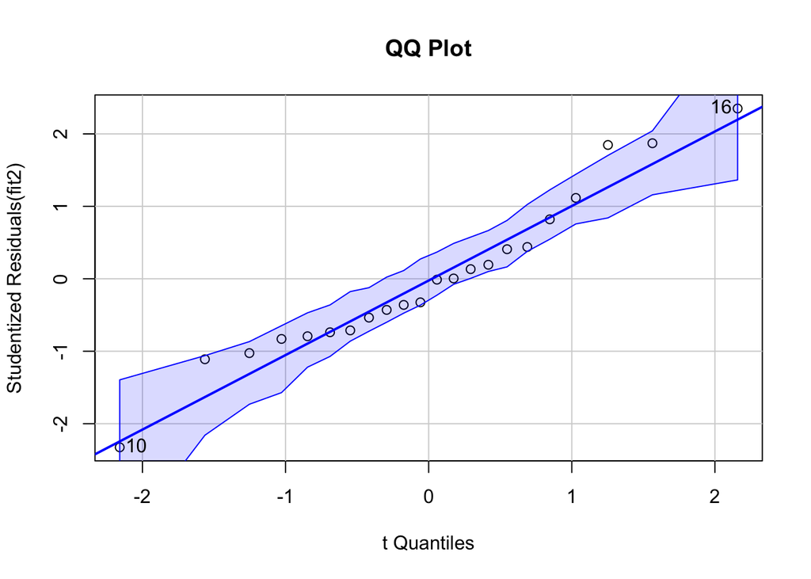

```
## [1] 10 16
```

```r
qqPlot(fit2, main="QQ Plot")
```

### Prediction

We set a data point with Instagram_value = 5, Whatsapp_Wechat_value = 5 and, job_interview_calls = 0, then the feeling score of the entire week we predict is approximate to 3

```r
predict.lm(fit2, data.frame(Instagram_value = 5, Whatsapp_Wechat_value = 5, job_interview_calls = 0))
```

```
##        1
## 3.211231
```

### Model Accuracy

The accuracy is based on summary of the model and we also calculate the MSE and RMSE for the model. The MSE is 0.3846858 and RMSE is 0.6202304.

```r
summary(fit2)
```

```
##
## Call:
## lm(formula = felt_the_entire_week ~ Instagram_value + Whatsapp_Wechat_value +
##     job_interview_calls, data = APP_data)
##
## Residuals:
##     Min      1Q  Median      3Q     Max
## -1.2875 -0.4729 -0.1141  0.2812  1.3214
##
## Coefficients:
##                       Estimate Std. Error t value Pr(>|t|)
## (Intercept)            3.21933    0.32034  10.050 8.28e-09 ***
## Instagram_value       -0.08406    0.05416  -1.552   0.1381
## Whatsapp_Wechat_value  0.08244    0.04544   1.814   0.0863 .
## job_interview_calls    0.63551    0.29687   2.141   0.0462 *
## ---
## Signif. codes:  0 '***' 0.001 '**' 0.01 '*' 0.05 '.' 0.1 ' ' 1
##
## Residual standard error: 0.6857 on 18 degrees of freedom
## Multiple R-squared:  0.2612, Adjusted R-squared:  0.138
## F-statistic: 2.121 on 3 and 18 DF,  p-value: 0.1332
```

```r
predictions <- predict(fit2, APP_data)
mse <- mean((APP_data$felt_the_entire_week - predictions)^2)
rmse <- sqrt(mse)
cat("MSE: ", mse, "\n")
```

```
## MSE:  0.3846858
```

```r
cat("RMSE: ", rmse, "\n")
```

```
## RMSE:  0.6202304
```